# Case Study 2

Hollie Gardner

4/06/2020

#Overview DDSAnalytics is an analytics company that specializes in talent management solutions for Fortune 100 companies. Talent management is defined as the iterative process of developing and retaining employees. Talent management includes: • workforce planning, • employee training programs, • identifying high-potential employees • reducing/preventing voluntary employee turnover (attrition). To gain a competitive edge over its competition, DDSAnalytics is planning to leverage data science for talent management. The executive leadership has identified predicting employee turnover as its first application of data science for talent management. Before the business greenlights the project, they have tasked your data science team to conduct an analysis of existing employee data. Audience is the CEO and CFO of Frito Lay (your client). The CEO is a statistician and the CFO has had only one class in statistics.

#Analysis

You have been given a dataset (CaseStudy2-data.csv) to do a data analysis to identify factors that lead to attrition.  
• Identify the top three factors that contribute to turnover (backed up by evidence provided by analysis). • There may or may not be a need to create derived attributes/variables/features. • Identify any job role specific trends that may exist in the data set (e.g., “Data Scientists have the highest job satisfaction”) • Provide any other interesting trends and observations from your analysis. • The analysis should be backed up by robust experimentation and appropriate visualization. Experiments and analysis must be conducted in R. • Build a model to predict attrition.

```r
colors2 <- c("#AB0E14", "#F1B11B")
colors3 <- c("#EF1C24", "#F1B11B","#000000")
colors4 <- c("#AB0E14", "#F1B11B", "#EF1C24","#000000")
colors5 <- c("#AB0E14", "#F1B11B", "#EF1C24", "#F1B11B", "#957531")
colors6 <- c("#AB0E14", "#F1B11B", "#EF1C24", "#F1B11B", "#957531", "#000000")

library(GGally)
```

```r
library(ggplot2)
library(corrplot)
library(naniar) #missing value vis
library(MASS)  #chi-sq table
library(magrittr)
library(dplyr)
library(caret)
library(e1071)
library(class)


CaseStudy2 <- read.csv("~/Desktop/CaseStudy2-data.csv")
```

#Tidying Data There were a number of variables that were defined as numeric, but were actually representations of factors. I removed the Employee Count, Over 18, and Standard Hours variables because these were all the same. I also didn’t the Employee ID number for this analysis.

```r
CaseStudy2$JobSatisfaction <- as.factor(CaseStudy2$JobSatisfaction)
CaseStudy2$EnvironmentSatisfaction <- as.factor(CaseStudy2$EnvironmentSatisfaction)
CaseStudy2$JobLevel <- as.factor(CaseStudy2$JobLevel)
CaseStudy2$JobInvolvement <- as.factor(CaseStudy2$JobInvolvement)
CaseStudy2$PerformanceRating <- as.factor(CaseStudy2$PerformanceRating)
CaseStudy2$RelationshipSatisfaction <- as.factor(CaseStudy2$RelationshipSatisfaction)
CaseStudy2$StockOptionLevel <- as.factor(CaseStudy2$StockOptionLevel)
CaseStudy2$WorkLifeBalance <- as.factor(CaseStudy2$WorkLifeBalance)
CaseStudy2$Education <- as.factor(CaseStudy2$Education)

#removing unnecessary columns
#Employee Count is all 1
CaseStudy2$EmployeeCount <- NULL

#Employee Number is an unnecessary ID number
CaseStudy2$EmployeeNumber <- NULL

#All employees are Over18
CaseStudy2$Over18 <- NULL

#All Employee Standard Hours are 80
CaseStudy2$StandardHours <-NULL
```

#Checking for missing values There are none.

```r
#missing values - all are present and no NA
#vis_miss(CaseStudy2)
#sum(is.na(CaseStudy2))
```

#Percentage of Attrition in Employees 16.1% of the 870 employees have left Frito Lay.

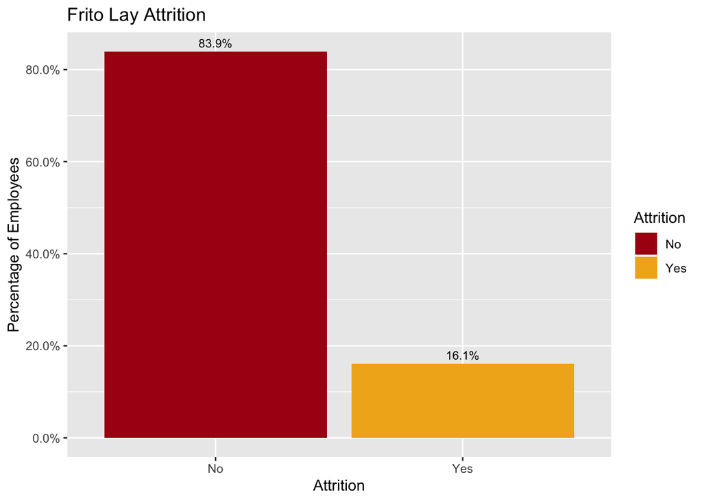

```r
CaseStudy2 %>%
  count(Attrition) %>%
  mutate(pct = prop.table(n)) %>%
  ggplot(aes(x = Attrition, y = pct, fill = Attrition, label = scales::percent(pct))) +
    geom_col(position = 'dodge') +
    geom_text(position = position_dodge(width = .9),    # move to center of bars
        vjust = -0.5,    # nudge above top of bar
        size = 3) + ylab("Percentage of Employees") + ggtitle("Frito Lay Attrition") + scale_y_continuous(labels = scales::percent) + scale_fill_manual(values = colors2)
```

#Attrition by Gender Female - 14.97% Male - 16.86%